# Why I like Quarto

Extraordinary data club meeting

Author

Teddy Groves

Published

June 14, 2023

# What is quarto?

Quarto is an app for writing scientific and technical documents.

Quarto is inspired by Rmarkdown: it works nicely with documents that contain Python, R or Julia code.

I used quarto to make this presentation!

# General idea

Write Markdown, use quarto to generate:

- Document (`.pdf`, `.doc`, `.tex`, `.epub`)
- Presentation (beamer, `.ppt`, revealjs)
- Jupyter notebook
- Website
- Book

# Command line workflow

1. Create `my_document.qmd`
2. Run `quarto preview my_document.qmd` (and leave it running).
3. Edit document, see live-updated output.
4. Run `quarto render my_document.qmd` to put document in a range of formats.

[Here](https://quarto.org/docs/get-started/hello/text-editor.html) is a detailed guide.

You can also go through these steps without leaving your editing environment. Here are guides for doing this using [VS code](https://quarto.org/docs/get-started/hello/vscode.html), [JupyterLab](https://quarto.org/docs/get-started/hello/jupyter.html), [R Studio](https://quarto.org/docs/get-started/hello/rstudio.html) and [neovim](https://quarto.org/docs/get-started/hello/neovim.html).

# How to install quarto

1. [Download the app](https://quarto.org/docs/get-started/).
2. Set up editor integration if desired.
3. Make sure you have Jupyter (for Python/Julia) and/or knitr (for R).

# How quarto Works

[figure not shown]

# Things I like about quarto

## Convenience

- Editor integration is good.
- Defaults look OK.
- One tool that does a lot of things.

## Collaboration

- Works on everyone’s setup
- Easy to send round HMTL, `.doc` etc.

## Plain text

- Git works.
- Easy to copy.
- Can use editor/language server etc.

# Code example

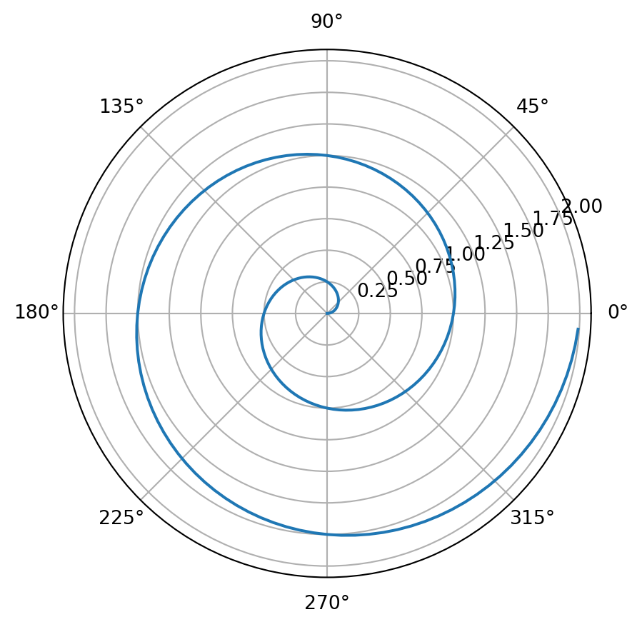

```python
import numpy as np
import matplotlib.pyplot as plt
r = np.arange(0, 2, 0.01)
theta = 2 * np.pi * r
ax = plt.subplot(projection="polar")
ax.plot(theta, r)
```

# Limitations

- Doesn’t support non Python/R/Julia code execution.
- Runs locally: everyone can’t edit the same document at once.
- Bring your own spelling/grammar checker.
- REPL integration requires separate setup.
- Relatively new.

# Alternatives

## Latex/overleaf

- Latex is fiddly.
- What if a `.doc` is needed?
- Code is a pain.

## Word/Google doc

- Bad for equations and figures.
- Code is a pain.
- A different window.

## Jupyter + nbconvert

- Doesn’t work with all editors.
- Citations, footnotes etc.
- Hard to version control.

## Plain Pandoc

- Have to write Makefiles and filters.

## Org mode

- Everyone has to use Emacs.
- Working with code is fiddly and slow.

## References

[1]

M. de Leeuw, M. R. A. Matos, and L. K. Nielsen, “Omics data for sampling thermodynamically feasible kinetic models,” *Metabolic Engineering*, vol. 78, pp. 41–47, Jul. 2023, doi: 10.1016/j.ymben.2023.05.002.

## Footnotes

[^1]: Like this one.